# Socioeconomic status and Democratization <South Africa, Botswana, and Kenya compared

# Descriptive Analyses

In this section, we will povide descriptive statistics of our variables.

## Democratization

Following graphs are trend of democratization for each countries.

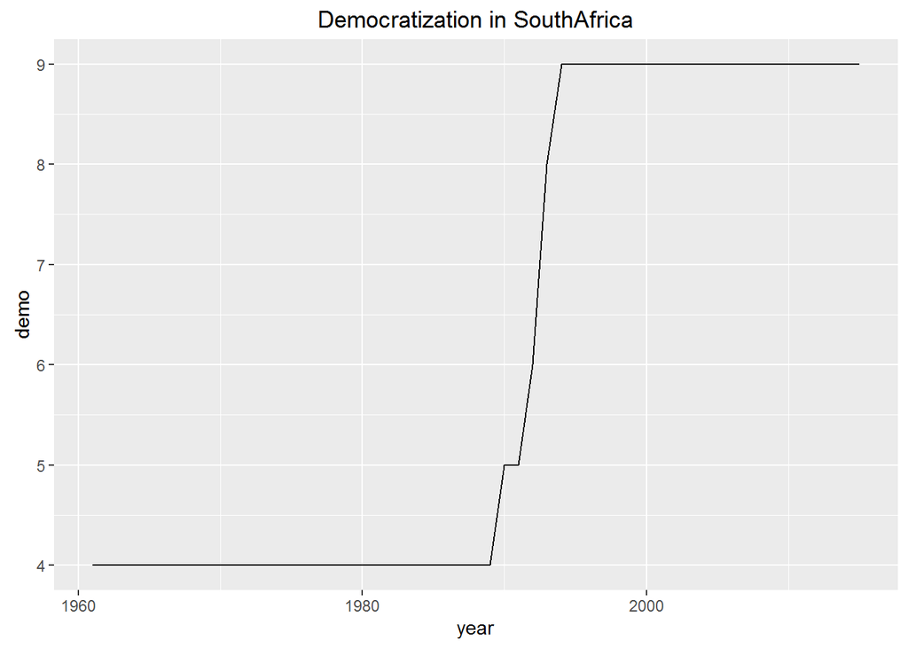

This is the trend of democratization in South Africa. As you can easily see, the level of democratization dramatically increased during 1990~1995. The contributor of this trend is the abolishment of Apartheid.

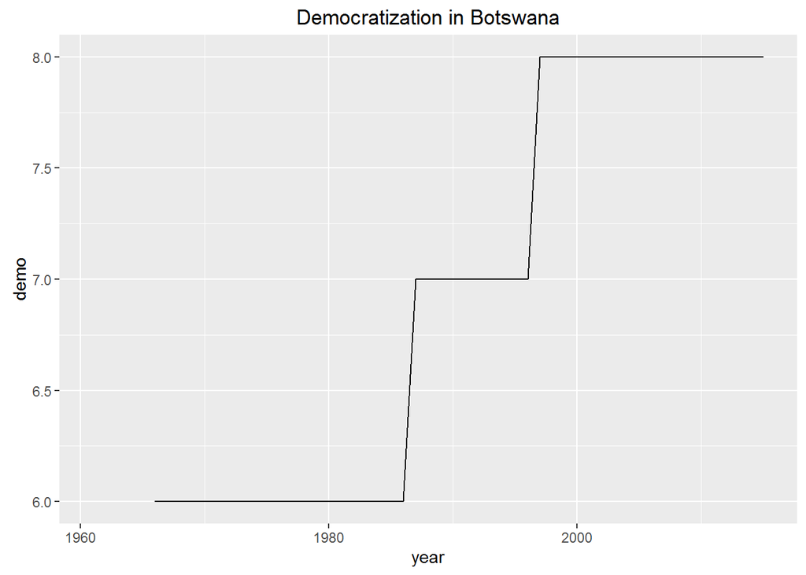

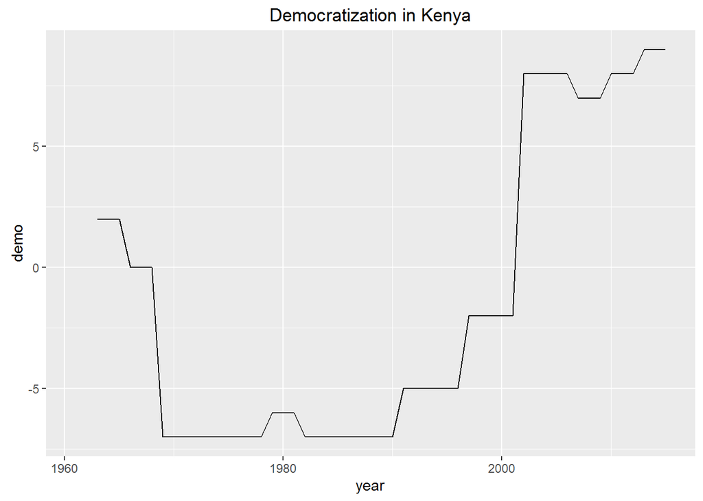

As graphs showing, the level of democratization has been fluctuated. Sometimes democracy advances, and sometimes it setbacks. We will investigate the data to clearify what is the driver of these fluctuation.